# Week 3 Short Answer Questions

## Gretchen Greene

Compiled on Tue Apr 4 14:00:14 2017.

5.1, 5.2, 6.5,6.6,6.7,6.8 7.1,7.4,7.5, 7.7, 7.11, 7.12

5.1)

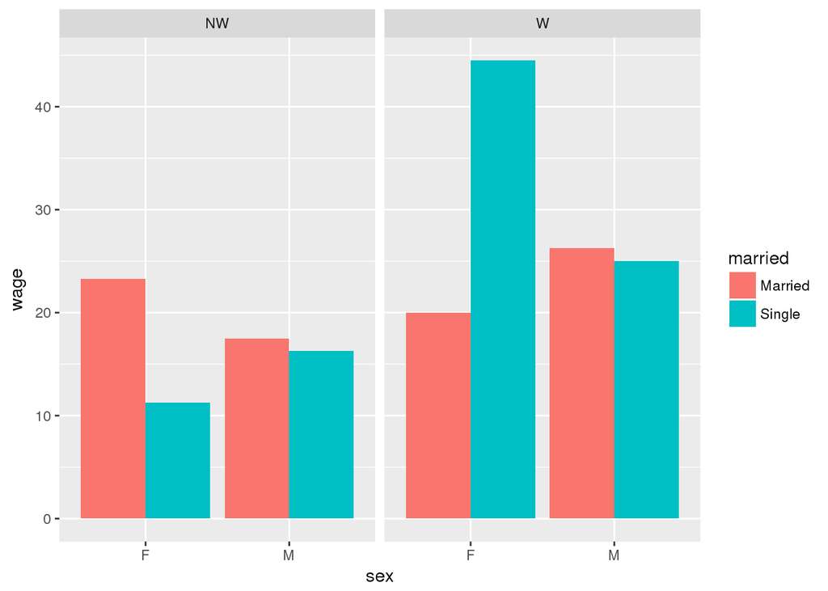

```r
library(mosaicData)
library(DataComputing)
ggplot(data=CPS85,aes(x=sex,y=wage ,fill=married))+geom_bar(stat='identity',position='dodge', width=.9)+ facet_wrap(~race,ncol=3)
```

5.2)

```
## Mapping API still under development and may change in future releases.
```

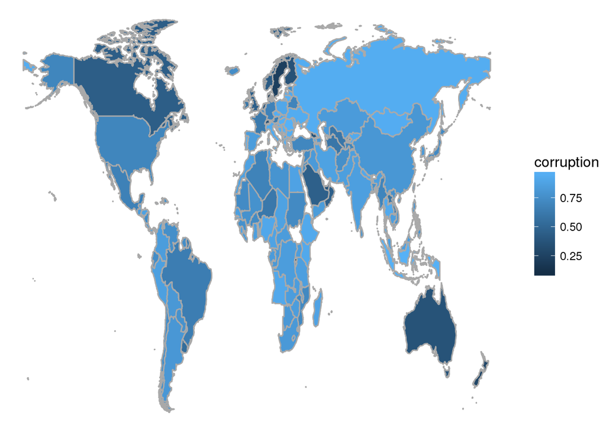

```r
library(mosaicData)
library(DataComputing)
WorldMap(HappinessIndex, key= country, fill=corruption )
```

6.5) b) state and polling organization

6.6) d) Glyph: Rectangle. Graphical attribute: color and text

6.7) a) state

6.8)

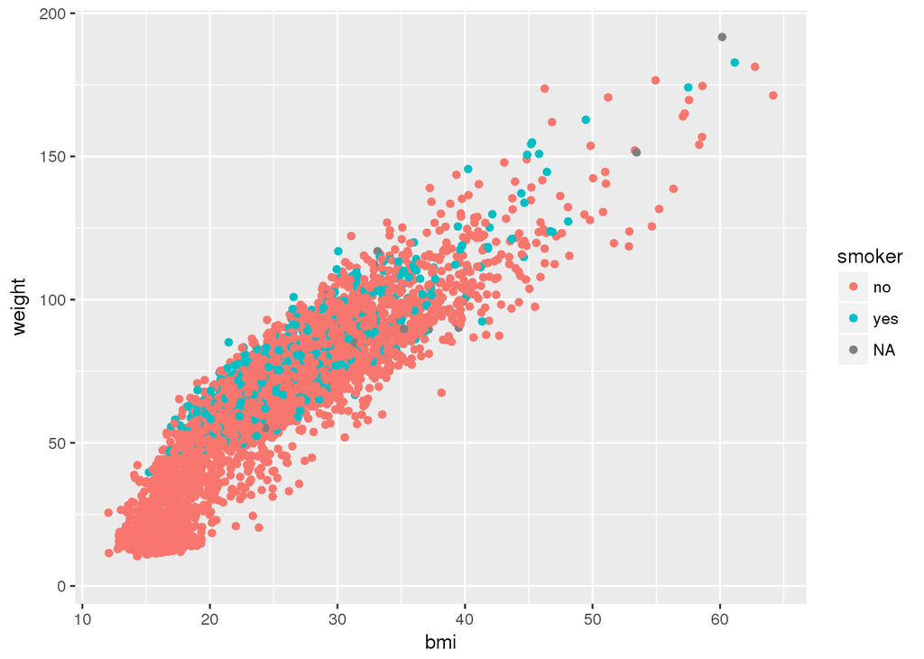

```r
Small <- NCHS %>%
  sample_n(size= 5000)
ggplot(data=Small,aes(x=bmi,y=weight))+geom_point()+aes(colour=smoker)
```

7.1) a) mean b) mutate c) arrange d) NewTable <- filter() e) select(A,X) f) group_by() and summarize()

7.4) a) b) Tmp should not be used in the second like. Tmp is being defined by the expression c) this is missing a pipe, %>% is needed after the first like

7.5) a) group_by(sex) and arrange(desc(count)) b) filter(sex==“F”) c) filter(sex==“M”, count >10) d) summarise(total = sum(count)) e) select(name, count)

7.7) a) Babynames appears at the start of the pipe and then again as an argument of group_by and summarise. It should not appear as an argument. BabyNames %>% group_by(year, sex)%>% summarise(total = sum(count))

2. ZipGeography should start the pipe. The <- is storing information. This should be replaced by %>%

ZipGeography %>% group_by(State) %>% summarise(pop = sum(Population))

c)the -> is an invalid symbol in this context. It should be replaced by a %>% Minneapolis2013%>% group_by(First)%>% summarise(voteReceived = n())

4. Minneapolis2013 should start the pipe not end it. Group_by should be before the summarise command.

Minneapolis2013%>% group_by(First) %>% summarise(votesReceived = n())

7.11) a) the variables sex, count, meanAge b) diagnosis, count, meanAge c) sex, diagnosis, count, meanAge d) age, diagnosis, count, meanAge e) age, count, meanAge

7.12) 1) nrow() 2) names() 3) help() 4) library() 5) group_by() 6) summarise()